# Os 3 lados de Meryl Streep

Vamos dar uma olhada nos filmes da atriz americana Meryl Streep para entender o perfil de seus trabalhos.

```r
filmes_streep = read_imported_data()
summary(filmes_streep)
```

```
##    avaliacao        filme              papel             bilheteria
##  Min.   :27.00   Length:25          Length:25          Min.   :  7.20
##  1st Qu.:55.00   Class :character   Class :character   1st Qu.: 22.20
##  Median :71.00   Mode  :character   Mode  :character   Median : 33.50
##  Mean   :65.76                                         Mean   : 51.03
##  3rd Qu.:80.00                                         3rd Qu.: 80.40
##  Max.   :92.00                                         Max.   :143.80
##       ano
##  Min.   :2002
##  1st Qu.:2006
##  Median :2008
##  Mean   :2009
##  3rd Qu.:2012
##  Max.   :2018
```

O resumo dos dados obtidos do Rotten Tomatoes mostra que ela tem filmes muito variados com bilheterias e avaliações altas e baixas. Ao mesmo tempo que estão concentrados nos anos 00’s e 10’s. Essa variação ambém revela na sua distribuição no gráfico dos dados.

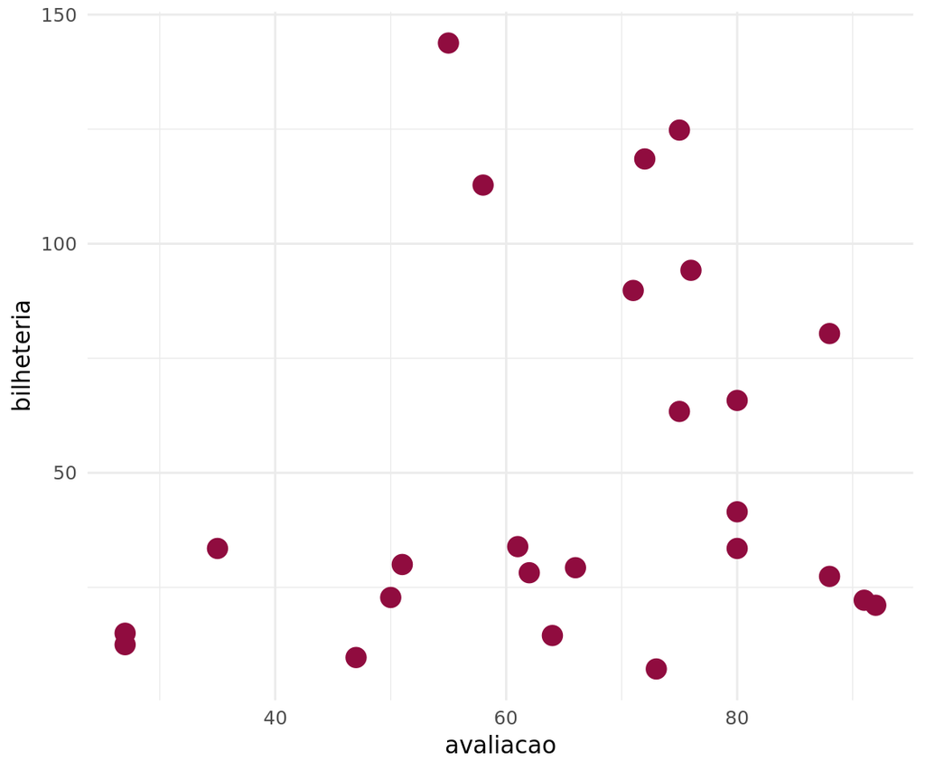

```r
filmes_streep %>%
    ggplot(aes(x = avaliacao, y = bilheteria)) +
    geom_point(size = 4, color="#900C3F")
```

Vendo a distribuição dos dados e testando, visualmente, agrupamentos, notamos que a divisão entre três grupos é satisfatória. Vemos um grupo de filmes maus de crítica e maus/bons de bilheteria; muito bons de crítica e maus/bons de bilheteria; e os sucessos de público e de bilheteria. Como exemplos de cada grupo podemos elencar os com maior bilheteria de cada, e talvez por isso mais conhecidos: The Giver, The Manchurian Candidate, Mamma Mia!

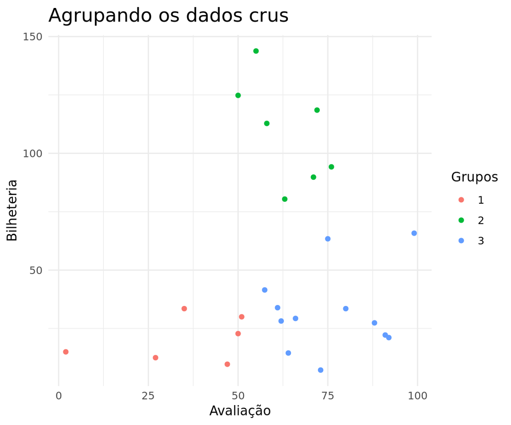

```r
m2 = filmes_streep %>% select(avaliacao, bilheteria) %>% as.matrix()
km_streep = kmeans(m2, 3, nstart = 15)%>%
        augment(filmes_streep) %>%
        mutate(.cluster = as.character(.cluster))

km_streep %>%
    ggplot(aes(x = avaliacao, y = bilheteria, color = .cluster), size = 100)  +
    geom_quasirandom(width = 50) +
    labs(title="Agrupando os dados crus", x="Avaliação", y="Bilheteria", color="Grupos")
```

A utilização de z-score como forma de normalizar os dados para realizar o agrupamento melhorou os resultados, apesar de, anteriormente, os grupos já estarem satisfatórios sob a informal análise visual e, de fato, permanecerem semelhantes.

[figure not shown]

```r
filme_normalizado = filmes_streep %>%
    mutate(bilheteria_normalizada = as.vector(scale(log10(bilheteria))),
           avaliacao_normalizada = as.vector(scale(avaliacao)))

m2 = filme_normalizado %>% select(avaliacao_normalizada, bilheteria_normalizada) %>% as.matrix()
km2 = kmeans(m2, 3, nstart = 15)%>%
        augment(filmes_streep) %>%
        mutate(.cluster = as.character(.cluster))

km2%>%
    ggplot(aes(x = avaliacao, y = bilheteria, color = .cluster), size = 10)  +
    geom_quasirandom(width = .5) +
    scale_y_log10() +
    labs(title="Agrupando os dados Normalizados", x="Avaliação Z-Norm", y="Bilheteria Z-Norm", color="Grupos")
```

Também é possível ver como os dados normalizados se dispõem em relação uns aos outros.

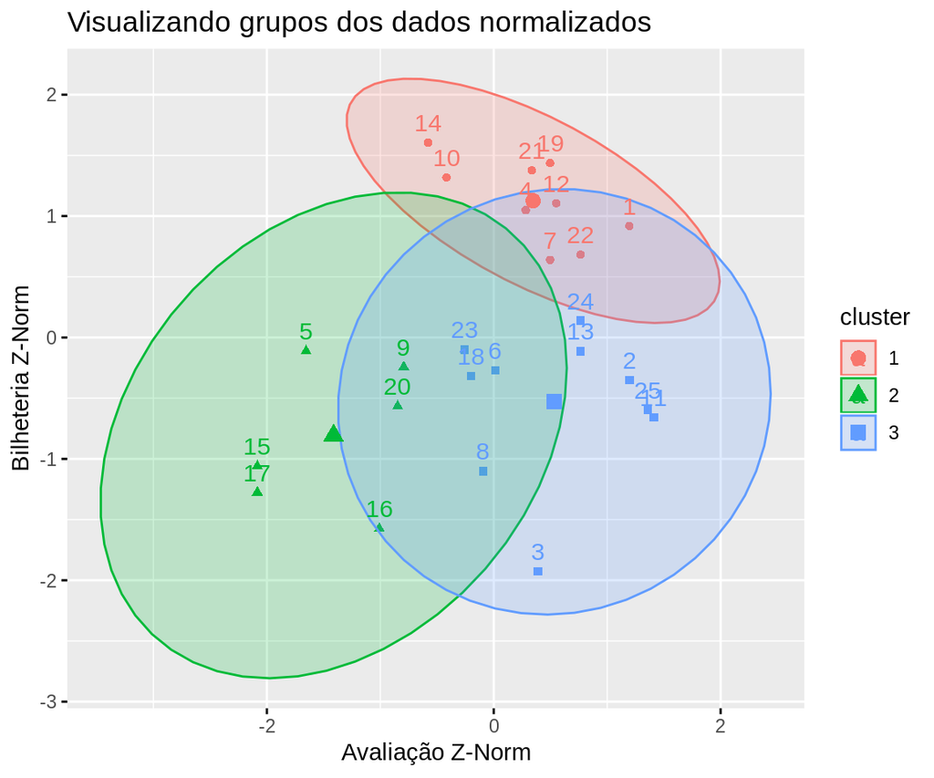

```r
km3 = kmeans(m2, 3, nstart = 15)
fviz_cluster(km3, m2, ellipse.type = "norm") +
    labs(title="Visualizando grupos dos dados normalizados ", x="Avaliação Z-Norm", y="Bilheteria Z-Norm")
```